# Exploratory analysis of archaeological ceramic compositions

### Cluster Analysis

Create the dendrograms based on the clr data. Required: define df_chem2 for numerical df_raw2 whole dataset (containing categorical data). If desired the emf and pdf can be directly saved to the local folder turning the argument of printDendro = TRUE, by default is false.

nplot: is the vector of plots to be displayed. Chose the index of categorical columns to be displayed.

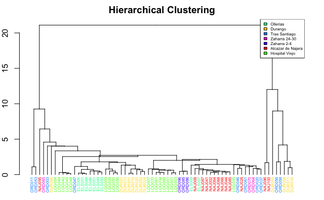

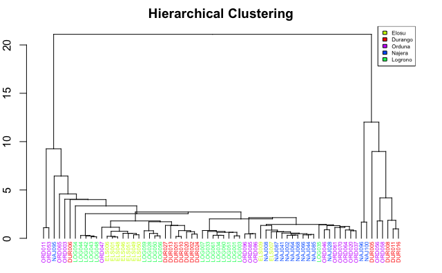

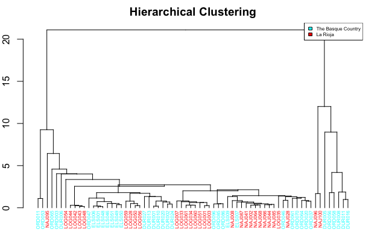

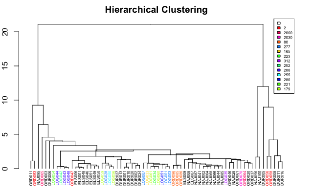

### Principal Component Analysis

For the alr transformation, the less variable element is generated in arch_uniformity and saved as .lvar. Here “.lvar” is read automatically. nplot: is the vector of plots to be displayed. Chose the index of categorical columns to be displayed. printPCA = TRUE for generating pdf and emf files.

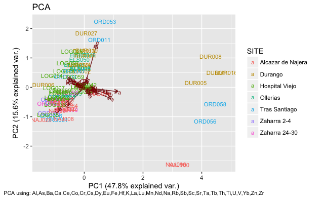

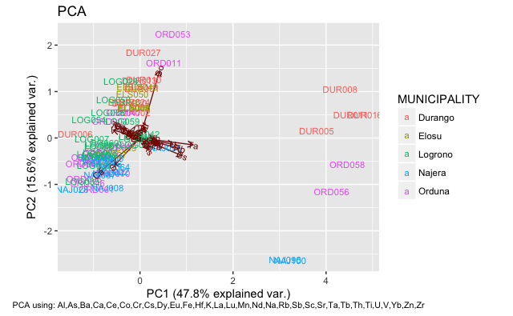